# Prerequsite test

### **Q1 How many multiplications and additions do you need to perform a matrix multiplication between a (n, k) and (k, m) matrix? Explain.**

**Soln: mxnxk**

Proof: To demonstrate that the total number of multiplication operations involved in multiplying two matrices of dimensions nxk and kxm are m×n×k.

\

Let, \

- A be a (n×k) matrix with elements a<sub>i,j</sub> \
- B be a (k,m) matrix with elements b<sub>i,j</sub>
- C be a resultant n×m matrix (After doing A × B) with elements c<sub>i,j</sub>

\ c<sub>i,j</sub> =$∑_{n=1}^{k}$ a<sub>i,n</sub> . b<sub>n,j</sub> \ For example consider, \ c<sub>1,1</sub> = a<sub>1,1</sub>. b<sub>1,1</sub> + a<sub>1,2</sub>. b<sub>2,1</sub> + a<sub>1,3</sub>. b<sub>3,1</sub>+......... +a<sub>1,k</sub>. b<sub>k,1</sub>

- Total multiplications performed = k.
- Total additions performed = k-1 (we need p-1 addition operations to add p elements).

This was just for one element, we need to fill n × m elements using this formula. So,

- Total multiplications = (n × m) × k = **n × m × k**
- Total additions = (n × m) × (k-1) = **n × m × k-1**

```
Initialize matrix C with dim n × m
for i from 1 to n do:
  for j from 1 to m do:
    C[i][j] = A[i][1] * B[1][j]

    for r from 2 to k do:
      C[i][j] = C[i][j] + (A[i][r] * B[r][j])
```

### **Q2 Write Python code to multiply the above two matrices. Solve using list of lists and then use numpy. Compare the timing of both solutions. Which one is faster? Why?**

```python
# Using List of lists
import time
import numpy as np

# A=[[1,2,3],[3,4,2]]
# B=[[4,2,3],[1,3,2],[2,4,3]]

time_list=[]
time_array=[]

for i in range(1,100):
  A=np.random.randint(1,10,size=(i,i)).tolist()
  B=np.random.randint(1,10,size=(i,i)).tolist()
  n=len(A)
  k=len(A[0])
  m=len(B[0])

  # C=[[0]*m]*n
  C = [[0] * m for _ in range(n)]

  start_time_lst=time.time()
  for i in range(n):
    for j in range(m):
      for p in range(k):
        C[i][j]+=(A[i][p]*B[p][j])
  end_time_lst=time.time()
  time_list.append(end_time_lst-start_time_lst)

  # using numpy

  import numpy as np
  A_arr=np.array(A)
  B_arr=np.array(B)

  start_time_np=time.time()
  C_arr=np.matmul(A,B)
  # C_arr=np.dot(A,B)
  end_time_np=time.time()
  time_array.append(end_time_np-start_time_np)
```

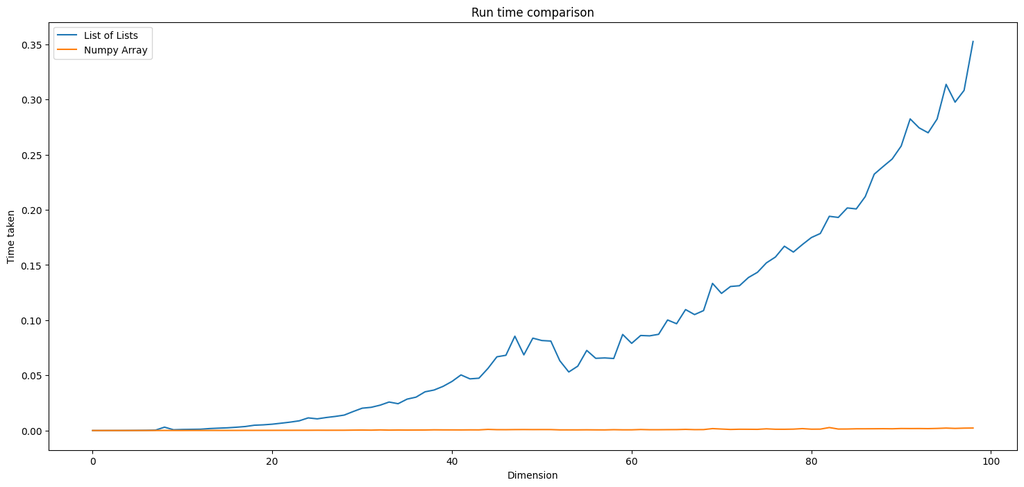

```python
# comparing times of both

import seaborn as sns
import matplotlib.pyplot as plt

plt.figure(figsize=(18,8))
plt.plot(time_list,label='List of Lists')
plt.plot(time_array,label='Numpy Array')

plt.xlabel('Dimension')
plt.ylabel('Time taken')

plt.title('Run time comparison')
plt.legend()

plt.show()
```

We see this huge difference in run time because of the following reasons:- \

- Numpy is implemented in lower level language (c) which is much faster than python. In list of list approach, there are python loops which are working on element by element. However, c is a compliled language and hence the operations are performed on entire array rather than element by element and it saves the interpret time during runtime.
- The numpy arrays are stored in contiguous memory, while the python lists are arrays of pointers to objects. So, a lot of time is wasted in getting data(in list of list approach). \

References:- \ https://numpy.org/doc/stable/reference/generated/numpy.matmul.html

### **Q3 Finding the highest element in a list requires one pass of the array. Finding the second highest element requires 2 passes of the the array. Using this method, what is the time complexity of finding the median of the array? Can you suggest a better method? Can you implement both these methods in Python and compare against numpy.median routine in terms of time?**

```python
# Using approach 1

def brute_force(arr,k):
  for i in range(k):
    curr_smallest=i
    for j in range(i,len(arr)):
      if arr[j]<arr[curr_smallest]:
        curr_smallest=j
    arr[i],arr[curr_smallest]=arr[curr_smallest],arr[i]
  return arr[k-1]
```

**Understanding the time complexity**

There are basically 2 for loops in total

- The first "for" loop works for k iterations. \
- The second "for" loop is actually a nested for loop, and goes from the ith index to end of array(finding the next smallest element in the pass).

So, total number of times the "if" statement is executed = $ n+(n-1)+(n-2)+(n-3)+....+(n-k)$ \ Which is approximately $O(n×k)$, where k is approximately n/2 (n is the size of array) \ $≈ O(n^2)$

```python
# using approach 2

def partition(arr,left,right):
  i,pivot=left-1,arr[right]
  for j in range(left,right):
    if arr[j]<pivot:
      i+=1
      arr[i],arr[j]=arr[j],arr[i]
  arr[i+1],arr[right]=arr[right],arr[i+1]
  return i+1


def quickselect(arr,left,right,k):
  if left==right:
    return arr[left]
  idx=partition(arr,left,right)
  if idx==k:
    return arr[idx]
  elif idx > k:
    return quickselect(arr,left,idx-1,k)
  else:
    return quickselect(arr,idx+1,right,k)
```

```python
# comparison
import time
import numpy as np

brute_force_time=[]
efficient_time=[]
routine_time=[]

for iter in range(2,100):
  arr=[np.random.randint(1,100) for _ in range(iter)]
  arr_ap1,arr_ap2,arr_ap3=arr,arr,arr            # duplicating data just to be sure that every function gets the same data, even if one function changes its data content.
  left=0
  right=len(arr)-1
  ans=0
  n=len(arr)
  if n%2==0:
    #approach 1
    start_time_ap1=time.time()
    mid1_ap1=brute_force(arr_ap1,n//2)
    mid2_ap1=brute_force(arr_ap1,n//2+1)
    ans_ap1=(mid1_ap1+mid2_ap1)/2
    brute_force_time.append(time.time()-start_time_ap1)

    #approach 2
    start_time_ap2=time.time()
    mid1_ap2=quickselect(arr_ap2,left,right,n//2-1)
    mid2_ap2=quickselect(arr_ap2,left,right,n//2)
    ans_ap2=(mid1_ap2+mid2_ap2)/2
    efficient_time.append(time.time()-start_time_ap2)

    #approach 3
    start_time_ap3=time.time()
    ans_ap3=np.median(arr_ap3)
    routine_time.append(time.time()-start_time_ap3)
  else:
    #approach 1
    start_time_ap1=time.time()
    ans_ap1=brute_force(arr_ap1,n//2)
    brute_force_time.append(time.time()-start_time_ap1)

    #approach 2
    start_time_ap2=time.time()
    ans_ap2=quickselect(arr,left,right,n//2)
    efficient_time.append(time.time()-start_time_ap2)

    #approach 3
    start_time_ap3=time.time()
    ans_ap3=np.median(arr_ap3)
    routine_time.append(time.time()-start_time_ap3)
```

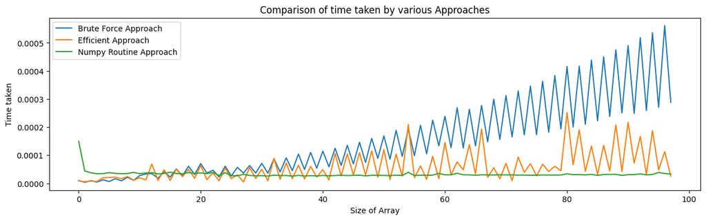

```python
import matplotlib.pyplot as plt
import seaborn as sns

plt.figure(figsize=(15,4))
plt.plot(brute_force_time,label='Brute Force Approach')
plt.plot(efficient_time,label='Efficient Approach')
plt.plot(routine_time,label='Numpy Routine Approach')
plt.title('Comparison of time taken by various Approaches')
plt.xlabel('Size of Array')
plt.ylabel('Time taken')
plt.legend()
plt.show()
```

### **Q4 What is the gradient of the following function with respect to x and y.**

- $x^2y + y^3 sin(x)$

**Soln**:- For finding the gradient of the fucntion $f(x,y)= x^2y + y^3 sin(x)$, we need to find the partial derivatives of the variables in the function i.e $\frac{∂f}{∂x},\frac{∂f}{∂y}.$ \ The gradient $∇f = (\frac{∂f}{∂x},\frac{∂f}{∂y})$ \

- Partial derivative of $f$ w.r.t $x$: \ $\frac{∂f}{∂x}=\frac{∂}{∂x}(f)=\frac{∂}{∂x}(x^2y + y^3 sin(x))=2xy+y^3cos(x)$ \ \
- Partial derivative of $f$ w.r.t $y$: \ $\frac{∂f}{∂y}=\frac{∂}{∂y}(f)=\frac{∂}{∂y}(x^2y + y^3 sin(x))=x^2+3y^2sin(x)$ \

\ The gradient $∇f = (2xy+y^3cos(x),x^2+3y^2sin(x))$

### **Q5 Use JAX to confirm the gradient evaluated by your method matches the analytical solution corresponding to a few random values of x and y**

```python
!pip install jax jaxlib
from jax import grad
import jax.numpy as jnp
import math
```

```python
#Manually calculating gradient
def manual_gradient(x,y):
  return [2*x*y+y**3*jnp.cos(x),x**2+3*y**2*jnp.sin(x)]


#Using JAX for gradient computation
def bivariate_func(x, y):
    return x**2*y+y**3*jnp.sin(x)

def jax_gradient(x,y):
  grad_fn = jax.grad(lambda vars: bivariate_func(vars[0], vars[1]))
  vars = jnp.array([x, y])
  gradient = grad_fn(vars)
  return gradient
```

```python
import numpy as np

#First
x=np.random.uniform(1,100)
y=np.random.uniform(1,100)
print(f'Gradient using manual calculation: {manual_gradient(x,y)}')
print(f'Gradient using JAX: {jax_gradient(x,y)}')
print()

#Second
x=jnp.array(np.random.uniform(1,100))
y=jnp.array(np.random.uniform(1,100))
print(f'Gradient using manual calculation: {manual_gradient(x,y)}')
print(f'Gradient using JAX: {jax_gradient(x,y)}')
```

```
Gradient using manual calculation: [Array(191771.23, dtype=float32, weak_type=True), Array(23489.201, dtype=float32, weak_type=True)]
Gradient using JAX: [191771.23   23489.203]

Gradient using manual calculation: [Array(-14527.283, dtype=float32, weak_type=True), Array(3944.105, dtype=float32, weak_type=True)]
Gradient using JAX: [-14527.283   3944.105]
```

[output not shown]

### **Q6 Use sympy to confirm that you obtain the same gradient analytically.**

```python
import sympy as sp
x,y=sp.symbols('x y')

function=x**2*y+y**3*sp.sin(x)
df_by_dx=sp.diff(function,x)
df_by_dy=sp.diff(function,y)

print(f'Derivative of function w.r.t x = {df_by_dx}')
print(f'Derivative of function w.r.t y = {df_by_dy}')
```

```
Derivative of function w.r.t x = 2*x*y + y**3*cos(x)
Derivative of function w.r.t y = x**2 + 3*y**2*sin(x)
```

### **Q7 Create a Python nested dictionary to represent hierarchical information. We want to store record of students and their marks.**

```python
{
    2022: {
      'Branch 1':{

          'stu1':{
              'Name':'xyz',
              'Roll_no':1,
              'Marks':{
                  'Sub1':78,
                  'Sub2':91
              },
          },

          'stu2':{
              'Name':'abc',
              'Roll_no':2,
              'Marks':{
                  'Sub1':74,
                  'Sub2':91,
                  'sub3':89
              },
          }
      },

      'Branch 2':{

          'stu3':{
              'Name':'bvh',
              'Roll_no':3,
              'Marks':{
                  'Sub1':79,
                  'Sub2':81

              }
          }
      }
    }
}
```

```
{2022: {'Branch 1': {'stu1': {'Name': 'xyz',
    'Roll_no': 1,
    'Marks': {'Sub1': 78, 'Sub2': 91}},
   'stu2': {'Name': 'abc',
    'Roll_no': 2,
    'Marks': {'Sub1': 74, 'Sub2': 91, 'sub3': 89}}},
  'Branch 2': {'stu3': {'Name': 'bvh',
    'Roll_no': 3,
    'Marks': {'Sub1': 79, 'Sub2': 81}}}}}
```

### Q8 **Store the same information using Python classes. We have an overall database which is a list of year objects. Each year contains a list of branches. Each branch contains a list of students. Each student has some properties like name, roll number and has marks in some subjects.**

```python
class year():
  def __init__(self,year_no):
    self.year=year_no
    self.branch=[]

  def add_new_branch(self,new_branch_obj):
    self.branch.append(new_branch_obj)

class Branch():
  def __init__(self,branch_name):
    self.branch=branch_name
    self.students=[]

  def add_new_student(self,student_obj):
    self.students.append(student_obj)


class student():
  def __init__(self,roll_no,name,marks):
    self.roll_no=roll_no
    self.marks=marks
    self.name=name

class Marks():
  def __init__(self,sub1,sub2,**kwargs):
    self.sub1=sub1
    self.sub2=sub2
    for sub_name,marks in kwargs.items():
      self.sub_name=marks


# So the structure looks like the following
"""
Year(
    year_no,
    Branch(
        branch_name,
        student(
            roll_no,
            name,
            Marks(
                sub1,sub2,sub3
                )
            )
        )
    )
"""
```

### **Q9 Using matplotlib plot the following functions on the domain: x = 0.5 to 100.0 in steps of 0.5.**

```python
import numpy as np
import matplotlib.pyplot as plt
x=np.arange(0.5,100,0.5)
```

$(i) y=x$

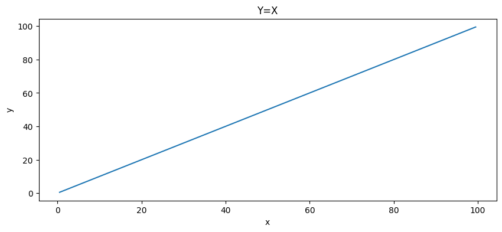

```python
y=x
plt.figure(figsize=(10,4))
plt.plot(x,y)
plt.xlabel('x')
plt.ylabel('y')
plt.title('Y=X')
plt.show()
```

$(ii) y=x^2$

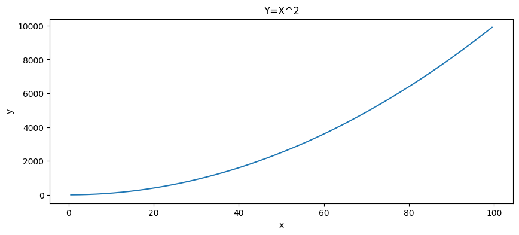

```python
y=x**2
plt.figure(figsize=(10,4))
plt.plot(x,y)
plt.xlabel('x')
plt.ylabel('y')
plt.title('Y=X^2')
plt.show()
```

$(iii) \frac{x^3}{100}$

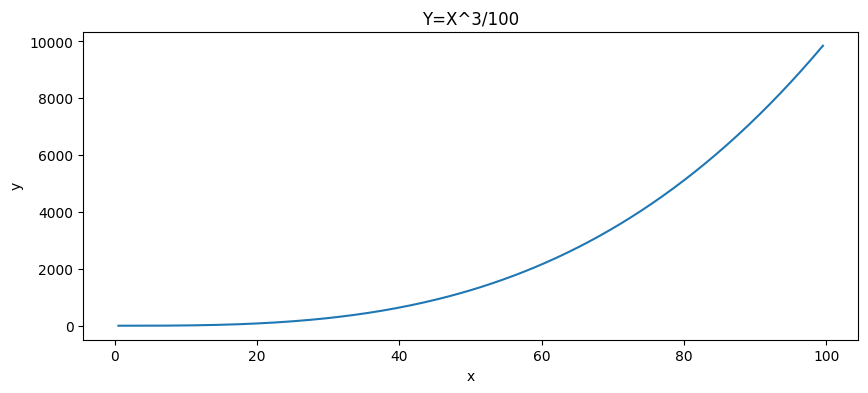

```python
y=x**3/100
plt.figure(figsize=(10,4))
plt.plot(x,y)
plt.xlabel('x')
plt.ylabel('y')
plt.title('Y=X^3/100')
plt.show()
```

$(iv) sin(x)$

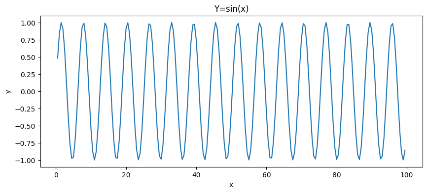

```python
y=np.sin(x)
plt.figure(figsize=(10,4))
plt.plot(x,y)
plt.xlabel('x')
plt.ylabel('y')
plt.title('Y=sin(x)')
plt.show()
```

$(v) \frac{sin(x)}{x}$

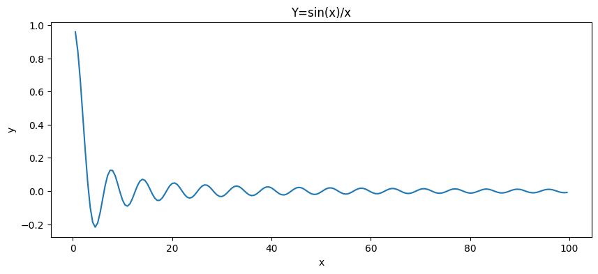

```python
y=np.sin(x)/x
plt.figure(figsize=(10,4))
plt.plot(x,y)
plt.xlabel('x')
plt.ylabel('y')
plt.title('Y=sin(x)/x')
plt.show()
```

$(vi) log(x)$

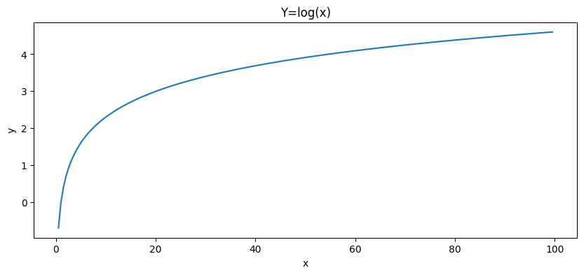

```python
y=np.log(x)
plt.figure(figsize=(10,4))
plt.plot(x,y)
plt.xlabel('x')
plt.ylabel('y')
plt.title('Y=log(x)')
plt.show()
```

$(vii) e^x$

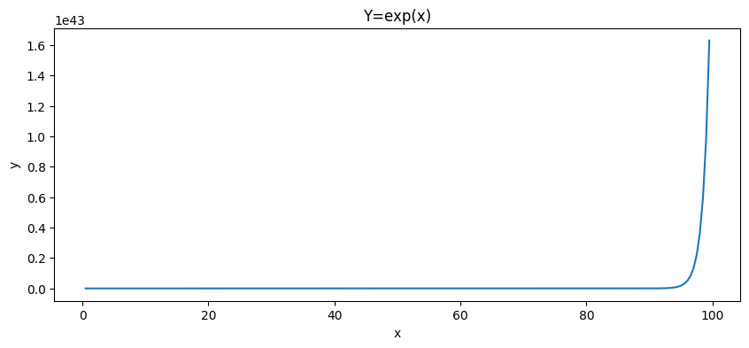

```python
y=np.exp(x)
plt.figure(figsize=(10,4))
plt.plot(x,y)
plt.xlabel('x')
plt.ylabel('y')
plt.title('Y=exp(x)')
plt.show()
```

### **Q10 Using numpy generate a matrix of size 20X5 containing random numbers drawn uniformly from the range of 1 to 2. Using Pandas create a dataframe out of this matrix. Name the columns of the dataframe as “a”, “b”, “c”, “d”, “e”. Find the column with the highest standard deviation. Find the row with the lowest mean.**

```python
import numpy as np
import pandas as pd

matrix=np.random.uniform(1,2,size=(20,5))
columns=['a','b','c','d','e']
df=pd.DataFrame(matrix,columns=columns)

max_std=float('-inf')
max_std_col='a'
for col_name in columns:
  curr_std=df[col_name].std()
  if max_std<curr_std:
    max_std=curr_std
    max_std_col=col_name

(f'Maximum standard deviation: {max_std} and column is {max_std_col}')
```

```
'Maximum standard deviation: 0.3058891958508874 and column is b'
```

```python
# Reference Pandas documentation  (https://pandas.pydata.org/pandas-docs/stable/reference/api/pandas.DataFrame.itertuples.html)

min_mean=float('inf')
min_mean_row_no=0
for row in df.itertuples():
  curr_mean=np.mean(row[1:])
  if curr_mean<min_mean:
    min_mean=curr_mean
    min_mean_row_no=row[0]
print(f'Minimum mean row number is {min_mean_row_no} with a mean of {min_mean}')
```

```
Minimum mean row number is 15 with a mean of 1.244426079683236
```

### **Q11 Add a new column to the dataframe called “f” which is the sum of the columns “a”, “b”, “c”, “d”, “e”. Create another column called “g”. The value in the column “g” should be “LT8” if the value in the column “f” is less than 8 and “GT8” otherwise. Find the number of rows in the dataframe where the value in the column “g” is “LT8”. Find the standard deviation of the column “f” for the rows where the value in the column “g” is “LT8” and “GT8” respectively.**

```python
backup=df
# Add a new column to the dataframe called “f” which is the sum of the columns “a”, “b”, “c”, “d”, “e”.
df['f']=0
for col in columns:
  df['f']+=df[col]

# Create another column called “g”. The value in the column “g” should be “LT8” if the value in the column “f” is less than 8 and “GT8” otherwise.
df['g']=df['f'].apply(lambda x: 'LT8' if x<8 else 'GT8' )

# Find the number of rows in the dataframe where the value in the column “g” is “LT8”.
print(f'The number of rows in the dataframe where the value in the column “g” is “LT8" are: {df[df["g"]=="LT8"].shape[0]}')

# Find the standard deviation of the column “f” for the rows where the value in the column “g” is “LT8” and “GT8” respectively.
std_LT8=0
std_GT8=0

std_LT8=df[df['g']=='LT8']['f'].std()
std_GT8=df[df['g']=='GT8']['f'].std()

print(f'The standard deviation of the column “f” for the rows where the value in the column “g” is “LT8” is {std_LT8}')
print(f'The standard deviation of the column “f” for the rows where the value in the column “g” is “GT8” is {std_GT8}')
```

```
The number of rows in the dataframe where the value in the column “g” is “LT8" are: 14
The standard deviation of the column “f” for the rows where the value in the column “g” is “LT8” is 0.4513006815668355
The standard deviation of the column “f” for the rows where the value in the column “g” is “GT8” is 0.24913079928762835
```

### **Q12 Write a small piece of code to explain broadcasting in numpy.**

```python
# Reference (https://numpy.org/doc/stable/user/basics.broadcasting.html)
import numpy as np

#Consider a scenario where we need to scale a vector with its mean value
vector=np.array([1,2,3])
mean=np.array([2,2,2])
new_vector=vector/mean    # Operation between 2 vectors (happens element wise)
new_vector
```

```
array([0.5, 1. , 1.5])
```

```python
# Now we notice that the value of mean is being copied in the mean vector, so it is not efficient, this is where Broadcasting comes into picture.
vector=np.array([1,2,3])
mean=2
new_vector=vector/mean     #Operation between a vector and a scaler
new_vector
```

```
array([0.5, 1. , 1.5])
```

- **So, how did it happen?** Why were we able to perform operation direclty between a vector and a scaler? This is with the help of broadcasting. Numpy actually creates virtual views of the smaller array.So we can think of the scaler being stretched to an array of the same size as that of the other vector. It does not replicates the data, but the same memory location is referenced multiple times, saving memory.
- Another important thing to note is that under the hood, the looping is done in highly efficient c language. C being a compiled language is much faster than python, So broadcasting is time efficient as well.

### **Q13 Write a function to compute the argmin of a numpy array. The function should take a numpy array as input and return the index of the minimum element. You can use the np.argmin function to verify your solution.**

```python
def argmin(array):
  min_element=float('inf')
  min_index=0
  for i,item in enumerate(array):
    if item<min_element:
      min_element=item
      min_index=i
  return min_index
test_array=np.array([9,7,4,2,4,2])
print(f'Answer using custom function: {argmin(test_array)}')
print(f'Answer using numpy argmin: {np.argmin(test_array)}')
```

```
Answer using custom function: 3
Answer using numpy argmin: 3
```